📗 Optimización de portafolios Pt. II | Optimización portafolio M-V | Taller optimización de portafolios | Taller optimización de portafolios Parte II | 🏠 Inicio del curso

# Optimización de portafolios — Parte II (Sharpe, grupos, límite de posiciones y ES)

Continuación del repaso de Media-Varianza (código de Andrés Salas, `Optimizacion portafolios Pt II.R`). Universo: los **30 primeros tickers** de `NASDAQ_NYSE.csv`, precios diarios de Yahoo Finance (2020-12-31 a 2026-09-30), convertidos a **retornos logarítmicos mensuales**. Sobre ellos se resuelven cuatro problemas con `PortfolioAnalytics` + solver `ROI`:

1. Portafolio M-V que **maximiza el Sharpe** (long-only, 100% invertido).
2. M-V con **restricciones por grupos** (sectores).
3. M-V con **límite de posiciones** (máximo 4 activos).
4. Portafolio **M-ES** (riesgo medido con Expected Shortfall) y su versión con grupos, apalancamiento parcial y cortos limitados.

> **Nota sobre una corrección al script original:** el script calculaba los retornos con `TTR::ROC(type = "continuous", na.pad = TRUE)` sobre la serie de `to.monthly()`. Aquí se usa `diff(log(precio))`, matemáticamente equivalente a $\ln(P_t/P_{t-1})$ y que evita el desalineamiento/crash conocido de `TTR::ROC` sobre series `xts` reagrupadas. También se omite el `setwd()` de RStudio, innecesario al renderizar.

## 0. Configuración y datos

**Qué hace:** carga paquetes, descarga precios ajustados de 30 acciones y calcula retornos mensuales. **Por qué (teoría):** el modelo de Markowitz solo necesita el vector de retornos esperados $\mu$ y la matriz de covarianzas $\Sigma$, que aquí se estiman con la media y covarianza muestral de los retornos mensuales. Se usan retornos logarítmicos porque son aditivos en el tiempo.

```r
if (!require("pacman")) install.packages("pacman")
pacman::p_load(tidyverse, xts, quantmod, TTR,
               stats, zoo, PerformanceAnalytics, PortfolioAnalytics, ROI,
               ROI.plugin.quadprog, ROI.plugin.glpk, DEoptim, corpcor, CVXR)
options(scipen = 999)
```

```r
free_rate <- 0.009489  # tasa libre de riesgo mensual usada en el taller

companies <- read_csv(file = "https://raw.githubusercontent.com/salas317/Data/main/NASDAQ_NYSE.csv",
                      show_col_types = FALSE)

activos <- companies$`Ticker Symbol`[1:30]

activos <- activos %>% gsub(pattern = "\\.",  replacement = "-", x = .)

precios <- quantmod::getSymbols(activos, src = 'yahoo',
                                from = "2020-12-31",
                                to = "2026-09-30",
                                periodicity = "daily",
                                auto.assign = T,
                                warnings = F) %>%
  purrr::map(~quantmod::Ad(get(.))) %>%
  purrr::reduce(merge.xts) %>%
  `colnames<-`(activos)
```

Retornos mensuales (logarítmicos):

```r
retornos_mes <- precios %>%
  xts::to.monthly(indexAt = "lastof", OHLC = F) %>%
  log() %>% diff() %>%
  na.omit()
dim(retornos_mes)
```

```
## [1] 69 30
```

**Ratio de Sharpe individual** de cada activo, con tres denominadores de riesgo (desviación estándar, VaR 95% y ES 95%):
$$S = \frac{E[R_p]-R_f}{\sigma_p}$$

```r
SharpeRatio(R = retornos_mes, Rf = 0, FUN = "StdDev")
```

```
##                                   NVDA      AAPL     GOOGL      MSFT       AMZN
## Sharpe Ratio (Rf=0%, p=95%): 0.3066104 0.1969915 0.2321823 0.1718189 0.06522142
##                                   AVGO      META       TSLA      LLY     BRK-A
## Sharpe Ratio (Rf=0%, p=95%): 0.3037163 0.1202799 0.03575499 0.323471 0.2150266
##                                     MU       JPM       WMT       AMD         V
## Sharpe Ratio (Rf=0%, p=95%): 0.2381198 0.2424293 0.2196227 0.1604907 0.1397601
##                                    JNJ        MA       INTC      ABBV    CSCO
## Sharpe Ratio (Rf=0%, p=95%): 0.2046387 0.1153102 0.08180506 0.2624956 0.21407
##                                   BAC       ORCL      COST       CVX      LRCX
## Sharpe Ratio (Rf=0%, p=95%): 0.135074 0.09634376 0.2124734 0.2043865 0.2235864
##                                     KO      AMAT       CAT       MRK        GE
## Sharpe Ratio (Rf=0%, p=95%): 0.1879709 0.2059012 0.2269389 0.1784313 0.2845333
```

```r
SharpeRatio(R = retornos_mes, Rf = 0, FUN = "VaR", p = 0.95)
```

```
##                                       NVDA      AAPL     GOOGL      MSFT
## VaR Sharpe Ratio (Rf=0%, p=95%): 0.2134418 0.1352134 0.1674558 0.1201247
##                                        AMZN      AVGO       META      TSLA
## VaR Sharpe Ratio (Rf=0%, p=95%): 0.04260018 0.2625459 0.07106188 0.0221178
##                                        LLY     BRK-A        MU       JPM
## VaR Sharpe Ratio (Rf=0%, p=95%): 0.2424859 0.1434818 0.2104285 0.1713152
##                                        WMT       AMD          V       JNJ
## VaR Sharpe Ratio (Rf=0%, p=95%): 0.1424423 0.1250563 0.09379931 0.1457221
##                                          MA      INTC      ABBV      CSCO
## VaR Sharpe Ratio (Rf=0%, p=95%): 0.07480754 0.0696584 0.1893085 0.1827677
##                                         BAC       ORCL      COST       CVX
## VaR Sharpe Ratio (Rf=0%, p=95%): 0.08633336 0.06032686 0.1374451 0.1400033
##                                       LRCX       KO      AMAT       CAT
## VaR Sharpe Ratio (Rf=0%, p=95%): 0.1531399 0.124033 0.1522278 0.1609504
##                                        MRK        GE
## VaR Sharpe Ratio (Rf=0%, p=95%): 0.1296381 0.2034939
```

```r
SharpeRatio(R = retornos_mes, Rf = 0, FUN = "ES", p = 0.95)
```

```
##                                      NVDA      AAPL     GOOGL       MSFT
## ES Sharpe Ratio (Rf=0%, p=95%): 0.1553749 0.1128237 0.1225711 0.09280908
##                                       AMZN      AVGO       META       TSLA
## ES Sharpe Ratio (Rf=0%, p=95%): 0.03253023 0.2075495 0.04618728 0.01728153
##                                       LLY     BRK-A       MU       JPM
## ES Sharpe Ratio (Rf=0%, p=95%): 0.1912667 0.1126646 0.171866 0.1317105
##                                       WMT       AMD          V      JNJ
## ES Sharpe Ratio (Rf=0%, p=95%): 0.1014517 0.1029805 0.07674883 0.121018
##                                         MA      INTC      ABBV      CSCO
## ES Sharpe Ratio (Rf=0%, p=95%): 0.06015396 0.0696584 0.1497161 0.1498118
##                                        BAC       ORCL      COST        CVX
## ES Sharpe Ratio (Rf=0%, p=95%): 0.06897317 0.04027576 0.1089263 0.09896963
##                                      LRCX        KO      AMAT       CAT
## ES Sharpe Ratio (Rf=0%, p=95%): 0.1091106 0.0914859 0.1091567 0.1224246
##                                       MRK        GE
## ES Sharpe Ratio (Rf=0%, p=95%): 0.1021765 0.1458807
```

## 2. Portafolio M-V que maximiza el Sharpe

**Qué hace:** pide al solver el portafolio de la frontera con mayor $(\mu_p-R_f)/\sigma_p$ (`maxSR = TRUE`), sin cortos y 100% invertido. **Por qué (teoría):** es el **portafolio tangente**: el punto donde la línea que sale de $R_f$ toca la frontera eficiente. `ROI` resuelve esto como un problema cuadrático convexo (cuadprog), por eso el óptimo es global.

```r
opt.sr <- activos %>%
  portfolio.spec() %>%
  add.constraint(type = "full_investment") %>%
  add.constraint(type = "long_only") %>%
  add.objective(type = "risk",
                name = "StdDev") %>%
  add.objective(type = "return",
                name = "mean") %>%
  optimize.portfolio(R = retornos_mes,
                     optimize_method = "ROI",
                     trace = T,
                     maxSR = TRUE)
opt.sr
```

```
## PortfolioAnalytics Optimization
##
## Call:
## optimize.portfolio(R = retornos_mes, portfolio = ., optimize_method = "ROI",
##     trace = T, maxSR = TRUE)
##
## Optimal Weights:
##   NVDA   AAPL  GOOGL   MSFT   AMZN   AVGO   META   TSLA    LLY  BRK-A     MU
## 0.0263 0.0000 0.0000 0.0000 0.0000 0.1535 0.0115 0.0000 0.2167 0.0000 0.0313
##    JPM    WMT    AMD      V    JNJ     MA   INTC   ABBV   CSCO    BAC   ORCL
## 0.0000 0.1157 0.0000 0.0000 0.0000 0.0000 0.0000 0.1786 0.0000 0.0000 0.0000
##   COST    CVX   LRCX     KO   AMAT    CAT    MRK     GE
## 0.0000 0.2090 0.0000 0.0000 0.0000 0.0000 0.0000 0.0575
##
## Objective Measure:
##  StdDev
## 0.04221
##
##
##    mean
## 0.02293
```

Riesgo-retorno de cada activo frente al portafolio óptimo, y la frontera eficiente (sin y con línea tangente a $R_f$):

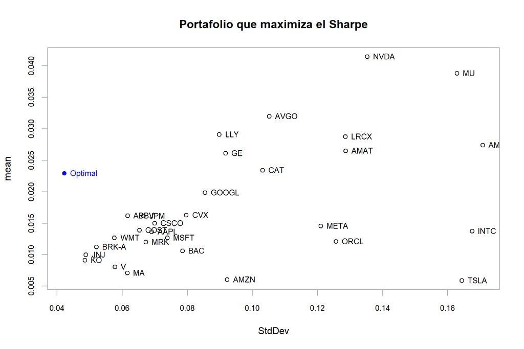

```r
PortfolioAnalytics::chart.RiskReward(opt.sr,
                                     risk.col = "StdDev",
                                     return.col = "mean",
                                     chart.assets = TRUE,
                                     rp = F,
                                     main = "Portafolio que maximiza el Sharpe")
```

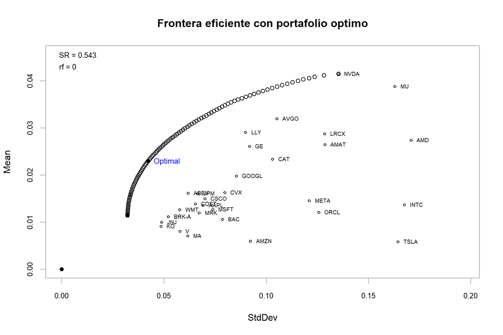

```r
PortfolioAnalytics::chart.EfficientFrontier(opt.sr,
                                            match.col = 'StdDev',
                                            main = "Frontera eficiente con portafolio optimo",
                                            cex.assets = 0.6,
                                            tangent.line = F,
                                            rf = 0,
                                            n.portfolios = 100)
```

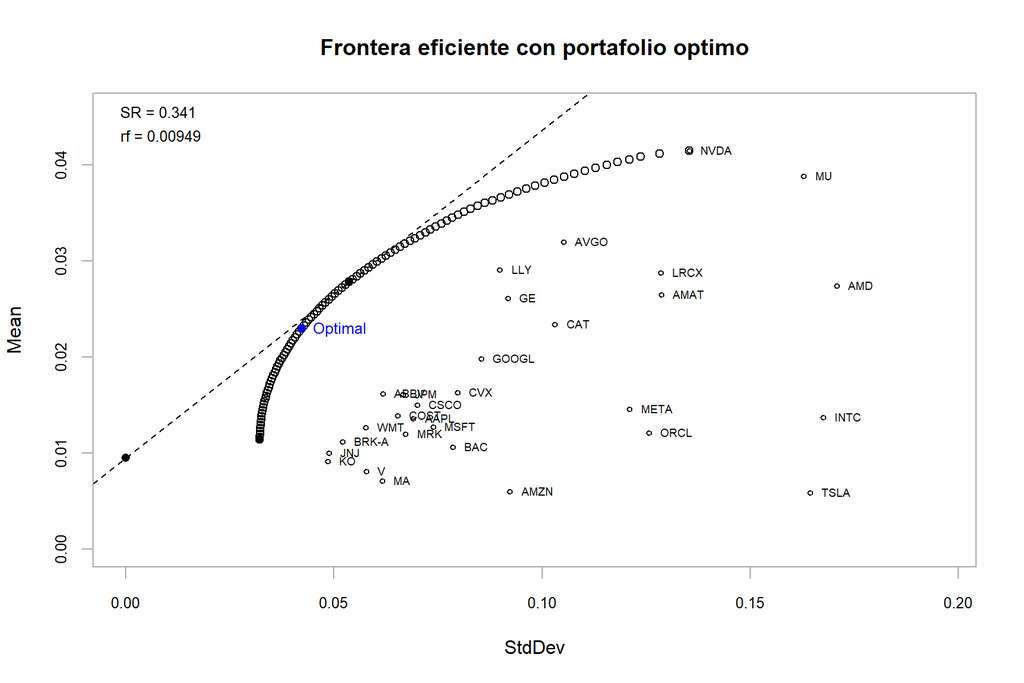

```r
PortfolioAnalytics::chart.EfficientFrontier(opt.sr,
                                            match.col = 'StdDev',
                                            main = "Frontera eficiente con portafolio optimo",
                                            cex.assets = 0.6,
                                            tangent.line = T,
                                            rf = free_rate,
                                            n.portfolios = 100)
```

### Resultados

```r
summary(opt.sr)
```

```
## PortfolioAnalytics Optimization Summary
##
## Call:
## optimize.portfolio(R = retornos_mes, portfolio = ., optimize_method = "ROI",
##     trace = T, maxSR = TRUE)
##
## Optimal Weights:
##   NVDA   AAPL  GOOGL   MSFT   AMZN   AVGO   META   TSLA    LLY  BRK-A     MU
## 0.0263 0.0000 0.0000 0.0000 0.0000 0.1535 0.0115 0.0000 0.2167 0.0000 0.0313
##    JPM    WMT    AMD      V    JNJ     MA   INTC   ABBV   CSCO    BAC   ORCL
## 0.0000 0.1157 0.0000 0.0000 0.0000 0.0000 0.0000 0.1786 0.0000 0.0000 0.0000
##   COST    CVX   LRCX     KO   AMAT    CAT    MRK     GE
## 0.0000 0.2090 0.0000 0.0000 0.0000 0.0000 0.0000 0.0575
##
## Objective Measures:
##  StdDev
## 0.04221
##
##
##    mean
## 0.02293
##
##
## Portfolio Assets and Initial Weights:
##       NVDA       AAPL      GOOGL       MSFT       AMZN       AVGO       META
## 0.03333333 0.03333333 0.03333333 0.03333333 0.03333333 0.03333333 0.03333333
##       TSLA        LLY      BRK-A         MU        JPM        WMT        AMD
## 0.03333333 0.03333333 0.03333333 0.03333333 0.03333333 0.03333333 0.03333333
##          V        JNJ         MA       INTC       ABBV       CSCO        BAC
## 0.03333333 0.03333333 0.03333333 0.03333333 0.03333333 0.03333333 0.03333333
##       ORCL       COST        CVX       LRCX         KO       AMAT        CAT
## 0.03333333 0.03333333 0.03333333 0.03333333 0.03333333 0.03333333 0.03333333
##        MRK         GE
## 0.03333333 0.03333333
##
## PortfolioAnalytics Portfolio Specification
##
## Call:
## portfolio.spec(assets = .)
##
```

[output cut: 103 more lines]

```
## $enabled
## [1] TRUE
##
## $multiplier
## [1] -1
##
## $call
## add.objective(portfolio = ., type = "return", name = "mean")
##
## attr(,"class")
## [1] "return_objective" "objective"
##
##
## Elapsed Time:
## Time difference of 0.2606971 secs
```

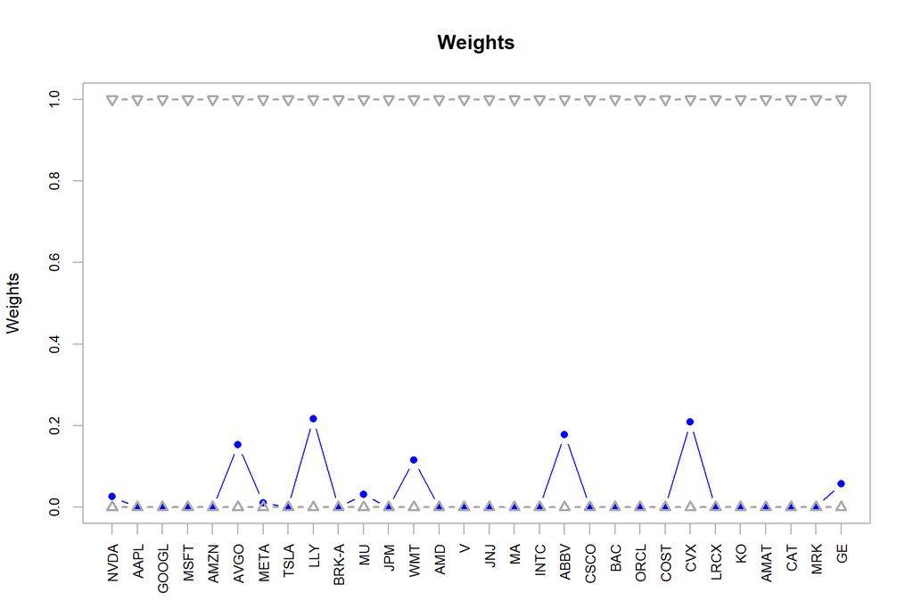

```r
chart.Weights(opt.sr)
```

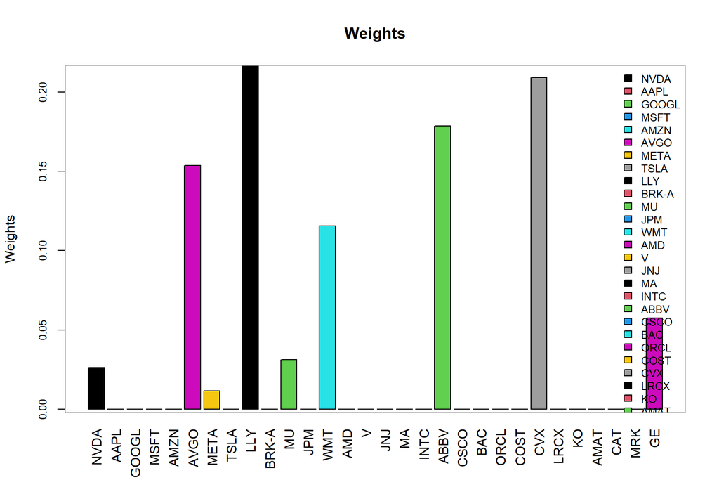

```r
chart.Weights(opt.sr, plot.type = "barplot")
```

```r
diversification(weights = opt.sr$weights)
```

```
## [1] 0.8354271
```

```r
HHI(weights = opt.sr$weights)
```

```
## [1] 0.1645729
```

```r
SharpeRatio(R = retornos_mes, Rf = 0, weights = opt.sr$weights, FUN = "StdDev")
```

```
##                                   [,1]
## Sharpe Ratio (Rf=0%, p=95%): 0.5433467
```

`diversification()` es $1-\sum w_i^2$ y `HHI` (Herfindahl) es $\sum w_i^2$: a más concentración, mayor HHI y menor diversificación.

## 3. M-V con restricciones por grupos

**Qué hace:** además de full-investment y long-only, limita el peso de cada sector (Tech 10-40%, Pharma 10-40%, Financial 10-30%, Other 10-30%). **Por qué (teoría):** cada restricción adicional recorta el conjunto factible, así que el Sharpe óptimo **no puede ser mayor** que el del caso sin restricciones; a cambio, el portafolio es más diversificado por sector.

```r
gr.portfolio <- activos %>%
  portfolio.spec() %>%
  add.constraint(type = "full_investment") %>%
  add.constraint(type = "long_only")

## 3.1. Restricciones de peso de los grupos ----

gr.portfolio <- gr.portfolio  %>%  add.constraint(type = "group",
                                               groups = list(Tech = c(1:8,11,14,18,20,22,25,27),
                                                             Pharma = c(9,16,29),
                                                             Financial = c(10,12,15,17,21),
                                                             Other = c(13,19,23,24,26,28,30)),
                                               group_min = c(0.1, 0.1, 0.1, 0.1),
                                               group_max = c(0.4, 0.4, 0.3, 0.3))

summary(gr.portfolio)
```

```
## $assets
##       NVDA       AAPL      GOOGL       MSFT       AMZN       AVGO       META
## 0.03333333 0.03333333 0.03333333 0.03333333 0.03333333 0.03333333 0.03333333
##       TSLA        LLY      BRK-A         MU        JPM        WMT        AMD
## 0.03333333 0.03333333 0.03333333 0.03333333 0.03333333 0.03333333 0.03333333
##          V        JNJ         MA       INTC       ABBV       CSCO        BAC
## 0.03333333 0.03333333 0.03333333 0.03333333 0.03333333 0.03333333 0.03333333
##       ORCL       COST        CVX       LRCX         KO       AMAT        CAT
## 0.03333333 0.03333333 0.03333333 0.03333333 0.03333333 0.03333333 0.03333333
##        MRK         GE
## 0.03333333 0.03333333
##
## $enabled_constraints
## $enabled_constraints[[1]]
## $type
## [1] "full_investment"
##
## $enabled
## [1] TRUE
##
## $message
## [1] FALSE
##
## $min_sum
## [1] 1
##
## $max_sum
## [1] 1
##
## $call
## add.constraint(portfolio = ., type = "full_investment")
##
## attr(,"class")
## [1] "weight_sum_constraint" "constraint"
##
## $enabled_constraints[[2]]
## $type
## [1] "long_only"
##
## $enabled
```

[output cut: 61 more lines]

```
## attr(,"class")
## [1] "group_constraint" "constraint"
##
##
## $disabled_constraints
## list()
##
## $enabled_objectives
## list()
##
## $disabled_objectives
## list()
##
## attr(,"class")
## [1] "summary.portfolio"
```

```r
## 3.2. Objetivos ----

gr.portfolio <- gr.portfolio %>% add.objective(type = "risk",
                                              name = "StdDev") %>%
  add.objective(type = "return",
                name = "mean")

summary(gr.portfolio)
```

```
## $assets
##       NVDA       AAPL      GOOGL       MSFT       AMZN       AVGO       META
## 0.03333333 0.03333333 0.03333333 0.03333333 0.03333333 0.03333333 0.03333333
##       TSLA        LLY      BRK-A         MU        JPM        WMT        AMD
## 0.03333333 0.03333333 0.03333333 0.03333333 0.03333333 0.03333333 0.03333333
##          V        JNJ         MA       INTC       ABBV       CSCO        BAC
## 0.03333333 0.03333333 0.03333333 0.03333333 0.03333333 0.03333333 0.03333333
##       ORCL       COST        CVX       LRCX         KO       AMAT        CAT
## 0.03333333 0.03333333 0.03333333 0.03333333 0.03333333 0.03333333 0.03333333
##        MRK         GE
## 0.03333333 0.03333333
##
## $enabled_constraints
## $enabled_constraints[[1]]
## $type
## [1] "full_investment"
##
## $enabled
## [1] TRUE
##
## $message
## [1] FALSE
##
## $min_sum
## [1] 1
##
## $max_sum
## [1] 1
##
## $call
## add.constraint(portfolio = ., type = "full_investment")
##
## attr(,"class")
## [1] "weight_sum_constraint" "constraint"
##
## $enabled_constraints[[2]]
## $type
## [1] "long_only"
##
## $enabled
```

[output cut: 106 more lines]

```
## $multiplier
## [1] -1
##
## $call
## add.objective(portfolio = ., type = "return", name = "mean")
##
## attr(,"class")
## [1] "return_objective" "objective"
##
##
## $disabled_objectives
## list()
##
## attr(,"class")
## [1] "summary.portfolio"
```

```r
opt.gr <- gr.portfolio %>% optimize.portfolio(R = retornos_mes,
                                             optimize_method = "ROI",
                                             trace = T,
                                             maxSR = TRUE)
opt.gr
```

```
## PortfolioAnalytics Optimization
##
## Call:
## optimize.portfolio(R = retornos_mes, portfolio = ., optimize_method = "ROI",
##     trace = T, maxSR = TRUE)
##
## Optimal Weights:
##   NVDA   AAPL  GOOGL   MSFT   AMZN   AVGO   META   TSLA    LLY  BRK-A     MU
## 0.0474 0.0000 0.0000 0.0000 0.0000 0.1605 0.0098 0.0000 0.2277 0.0000 0.0340
##    JPM    WMT    AMD      V    JNJ     MA   INTC   ABBV   CSCO    BAC   ORCL
## 0.1000 0.0346 0.0000 0.0000 0.1041 0.0000 0.0000 0.0932 0.0000 0.0000 0.0000
##   COST    CVX   LRCX     KO   AMAT    CAT    MRK     GE
## 0.0000 0.1639 0.0000 0.0000 0.0000 0.0000 0.0163 0.0083
##
## Objective Measure:
##  StdDev
## 0.04316
##
##
##    mean
## 0.02286
```

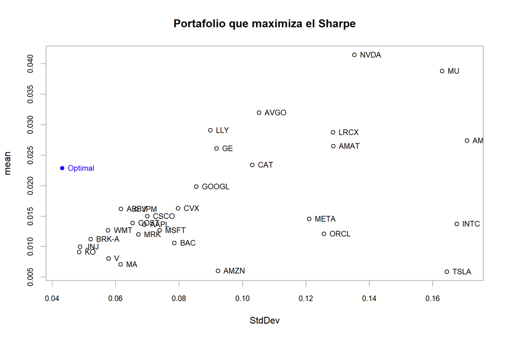

```r
PortfolioAnalytics::chart.RiskReward(opt.gr,
                                     risk.col = "StdDev",
                                     return.col = "mean",
                                     chart.assets = TRUE,
                                     main = "Portafolio que maximiza el Sharpe")
```

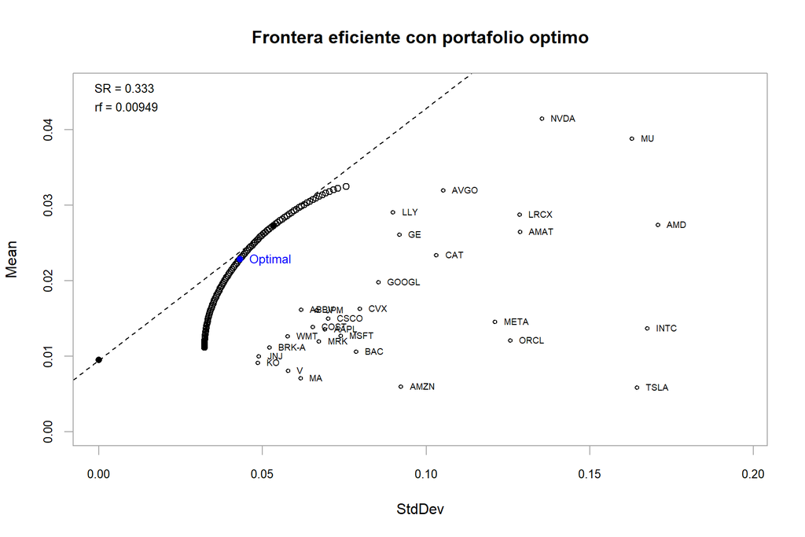

```r
PortfolioAnalytics::chart.EfficientFrontier(opt.gr,
                                            match.col = 'StdDev',
                                            main = "Frontera eficiente con portafolio optimo",
                                            cex.assets = 0.6,
                                            tangent.line = T,
                                            rf = free_rate,
                                            n.portfolios = 100)
```

```r
summary(opt.gr)
```

```
## PortfolioAnalytics Optimization Summary
##
## Call:
## optimize.portfolio(R = retornos_mes, portfolio = ., optimize_method = "ROI",
##     trace = T, maxSR = TRUE)
##
## Optimal Weights:
##   NVDA   AAPL  GOOGL   MSFT   AMZN   AVGO   META   TSLA    LLY  BRK-A     MU
## 0.0474 0.0000 0.0000 0.0000 0.0000 0.1605 0.0098 0.0000 0.2277 0.0000 0.0340
##    JPM    WMT    AMD      V    JNJ     MA   INTC   ABBV   CSCO    BAC   ORCL
## 0.1000 0.0346 0.0000 0.0000 0.1041 0.0000 0.0000 0.0932 0.0000 0.0000 0.0000
##   COST    CVX   LRCX     KO   AMAT    CAT    MRK     GE
## 0.0000 0.1639 0.0000 0.0000 0.0000 0.0000 0.0163 0.0083
##
## Objective Measures:
##  StdDev
## 0.04316
##
##
##    mean
## 0.02286
##
##
## Portfolio Assets and Initial Weights:
##       NVDA       AAPL      GOOGL       MSFT       AMZN       AVGO       META
## 0.03333333 0.03333333 0.03333333 0.03333333 0.03333333 0.03333333 0.03333333
##       TSLA        LLY      BRK-A         MU        JPM        WMT        AMD
## 0.03333333 0.03333333 0.03333333 0.03333333 0.03333333 0.03333333 0.03333333
##          V        JNJ         MA       INTC       ABBV       CSCO        BAC
## 0.03333333 0.03333333 0.03333333 0.03333333 0.03333333 0.03333333 0.03333333
##       ORCL       COST        CVX       LRCX         KO       AMAT        CAT
## 0.03333333 0.03333333 0.03333333 0.03333333 0.03333333 0.03333333 0.03333333
##        MRK         GE
## 0.03333333 0.03333333
##
## PortfolioAnalytics Portfolio Specification
##
## Call:
## portfolio.spec(assets = .)
##
```

[output cut: 130 more lines]

```
## $enabled
## [1] TRUE
##
## $multiplier
## [1] -1
##
## $call
## add.objective(portfolio = ., type = "return", name = "mean")
##
## attr(,"class")
## [1] "return_objective" "objective"
##
##
## Elapsed Time:
## Time difference of 0.223772 secs
```

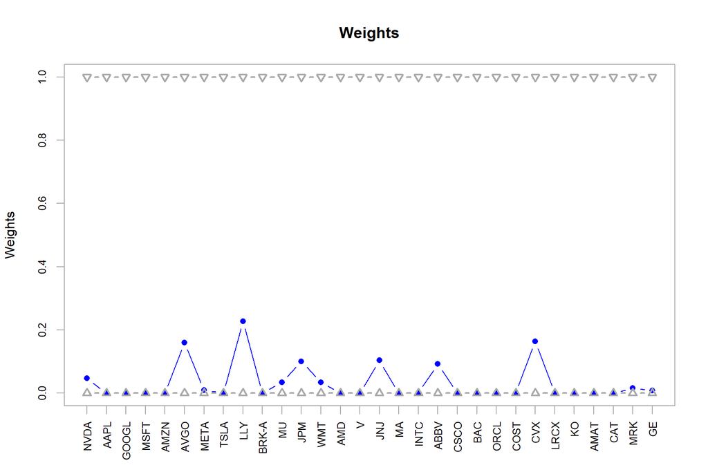

```r
chart.Weights(opt.gr)
```

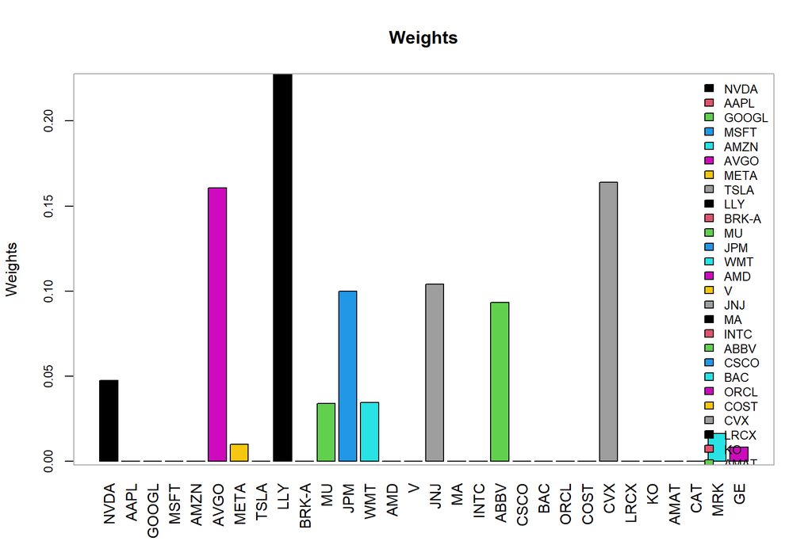

```r
chart.Weights(opt.gr, plot.type = "barplot")
```

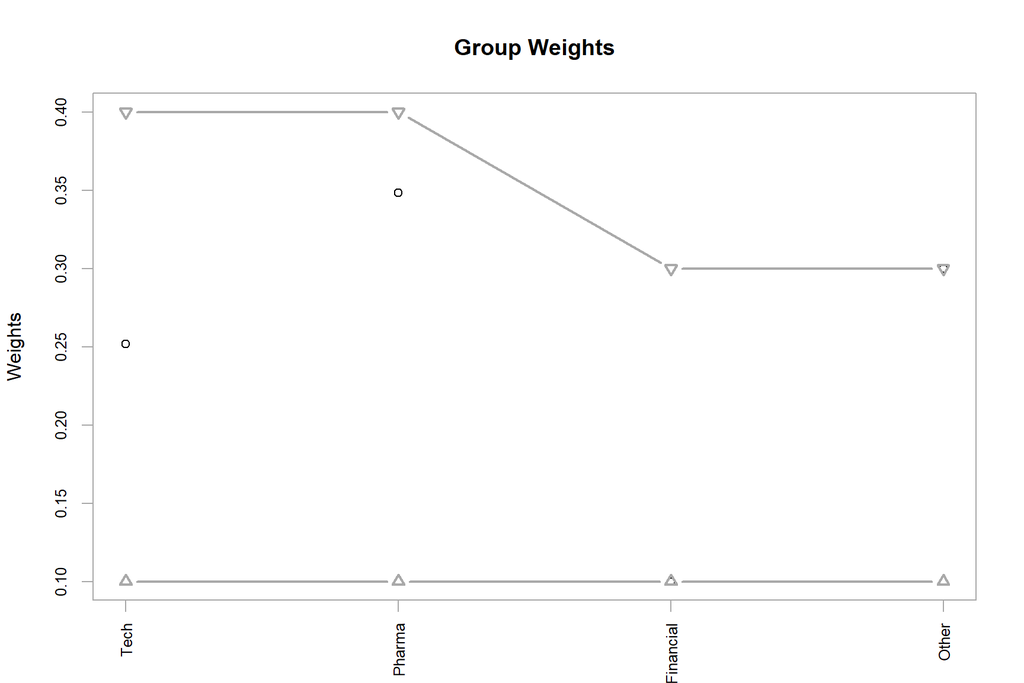

```r
chart.GroupWeights(opt.gr)
```

```r
diversification(weights = opt.gr$weights)
```

```
## [1] 0.8609195
```

```r
SharpeRatio(R = retornos_mes, Rf = free_rate, weights = opt.gr$weights, FUN = "StdDev")
```

```
##                                    [,1]
## Sharpe Ratio (Rf=0.9%, p=95%): 0.309777
```

## 5. M-V con límite de posiciones

**Qué hace:** restringe el portafolio a **máximo 4 activos** (`position_limit`), con pesos entre 0 y 1 y sin cortos. **Por qué (teoría):** limitar el número de posiciones vuelve el problema **combinatorio** (entera mixta), no convexo puro; `ROI` lo maneja con variables binarias. Con `maxSR = FALSE` maximiza la **utilidad cuadrática** $\mu_p - \tfrac{\lambda}{2}\sigma_p^2$ (no el Sharpe), y concentra el capital en pocos activos.

```r
pos.portfolio <- PortfolioAnalytics::portfolio.spec(assets = activos)

## 5.2 Restricciones ----

### 5.2.1. Uso de todo el capital ----

pos.portfolio <- PortfolioAnalytics::add.constraint(portfolio = pos.portfolio,
                                                   type = "full_investment")

### 5.2.2. Limite de posiciones ----

pos.portfolio <- PortfolioAnalytics::add.constraint(portfolio = pos.portfolio,
                                                   type = "position_limit",
                                                   max_pos_long = 4,
                                                   max_pos_short = 0)

pos.portfolio <- PortfolioAnalytics::add.constraint(portfolio = pos.portfolio,
                                                     type = "box", min = 0, max = 1)

## 5.3. Objetivos ----

### 5.3.1. Riesgo como desviacion estandar ----

pos.portfolio <- PortfolioAnalytics::add.objective(portfolio = pos.portfolio,
                                                  type = "risk",
                                                  name = "StdDev")

### 5.3.2. Rentabilidad como media de los retornos ----

pos.portfolio <- PortfolioAnalytics::add.objective(portfolio = pos.portfolio,
                                                  type = "return",
                                                  name = "mean")

summary(pos.portfolio)
```

```
## $assets
##       NVDA       AAPL      GOOGL       MSFT       AMZN       AVGO       META
## 0.03333333 0.03333333 0.03333333 0.03333333 0.03333333 0.03333333 0.03333333
##       TSLA        LLY      BRK-A         MU        JPM        WMT        AMD
## 0.03333333 0.03333333 0.03333333 0.03333333 0.03333333 0.03333333 0.03333333
##          V        JNJ         MA       INTC       ABBV       CSCO        BAC
## 0.03333333 0.03333333 0.03333333 0.03333333 0.03333333 0.03333333 0.03333333
##       ORCL       COST        CVX       LRCX         KO       AMAT        CAT
## 0.03333333 0.03333333 0.03333333 0.03333333 0.03333333 0.03333333 0.03333333
##        MRK         GE
## 0.03333333 0.03333333
##
## $enabled_constraints
## $enabled_constraints[[1]]
## $type
## [1] "full_investment"
##
## $enabled
## [1] TRUE
##
## $message
## [1] FALSE
##
## $min_sum
## [1] 1
##
## $max_sum
## [1] 1
##
## $call
## PortfolioAnalytics::add.constraint(portfolio = pos.portfolio,
##     type = "full_investment")
##
## attr(,"class")
## [1] "weight_sum_constraint" "constraint"
##
## $enabled_constraints[[2]]
## $type
## [1] "position_limit"
##
```

[output cut: 102 more lines]

```
## [1] -1
##
## $call
## PortfolioAnalytics::add.objective(portfolio = pos.portfolio,
##     type = "return", name = "mean")
##
## attr(,"class")
## [1] "return_objective" "objective"
##
##
## $disabled_objectives
## list()
##
## attr(,"class")
## [1] "summary.portfolio"
```

```r
opt.pos <- PortfolioAnalytics::optimize.portfolio(R = retornos_mes,
                                                 portfolio = pos.portfolio,
                                                 optimize_method = "ROI",
                                                 trace = T,
                                                 maxSR = FALSE)
opt.pos
```

```
## PortfolioAnalytics Optimization
##
## Call:
## PortfolioAnalytics::optimize.portfolio(R = retornos_mes, portfolio = pos.portfolio,
##     optimize_method = "ROI", trace = T, maxSR = FALSE)
##
## Optimal Weights:
##   NVDA   AAPL  GOOGL   MSFT   AMZN   AVGO   META   TSLA    LLY  BRK-A     MU
## 0.4128 0.0000 0.0000 0.0000 0.0000 0.1028 0.0000 0.0000 0.3363 0.0000 0.1481
##    JPM    WMT    AMD      V    JNJ     MA   INTC   ABBV   CSCO    BAC   ORCL
## 0.0000 0.0000 0.0000 0.0000 0.0000 0.0000 0.0000 0.0000 0.0000 0.0000 0.0000
##   COST    CVX   LRCX     KO   AMAT    CAT    MRK     GE
## 0.0000 0.0000 0.0000 0.0000 0.0000 0.0000 0.0000 0.0000
##
## Objective Measure:
##    mean
## 0.03592
##
##
##  StdDev
## 0.08581
```

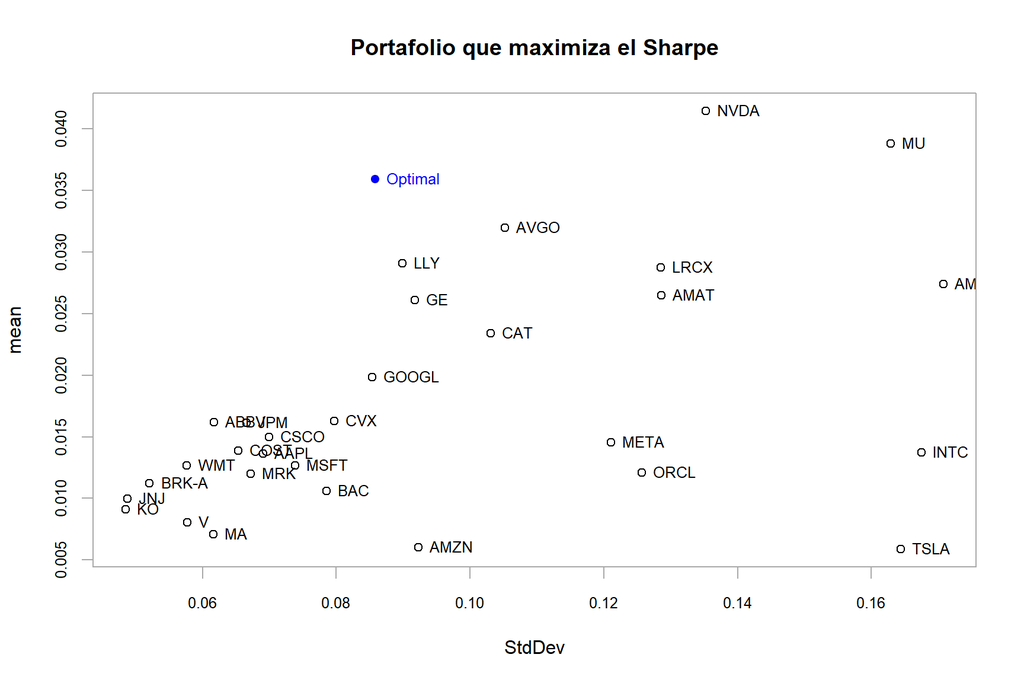

```r
PortfolioAnalytics::chart.RiskReward(opt.pos,
                                     risk.col = "StdDev",
                                     return.col = "mean",
                                     chart.assets = TRUE,
                                     main = "Portafolio que maximiza el Sharpe")
```

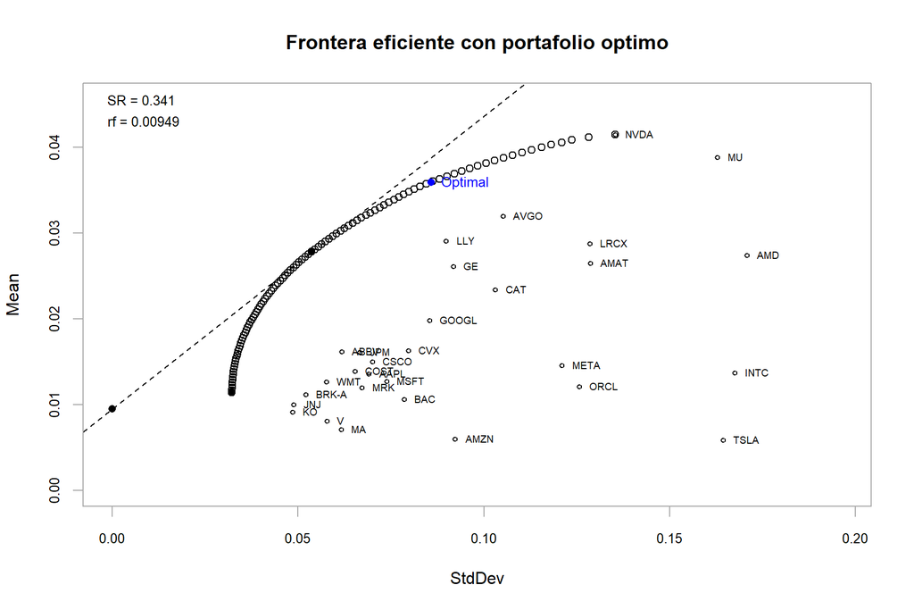

```r
PortfolioAnalytics::chart.EfficientFrontier(opt.pos,
                                            match.col = 'StdDev',
                                            main = "Frontera eficiente con portafolio optimo",
                                            cex.assets = 0.6,
                                            tangent.line = T,
                                            rf = free_rate,
                                            n.portfolios = 100)
```

```r
## 5.5. Resultados ----

summary(opt.pos)
```

```
## PortfolioAnalytics Optimization Summary
##
## Call:
## PortfolioAnalytics::optimize.portfolio(R = retornos_mes, portfolio = pos.portfolio,
##     optimize_method = "ROI", trace = T, maxSR = FALSE)
##
## Optimal Weights:
##   NVDA   AAPL  GOOGL   MSFT   AMZN   AVGO   META   TSLA    LLY  BRK-A     MU
## 0.4128 0.0000 0.0000 0.0000 0.0000 0.1028 0.0000 0.0000 0.3363 0.0000 0.1481
##    JPM    WMT    AMD      V    JNJ     MA   INTC   ABBV   CSCO    BAC   ORCL
## 0.0000 0.0000 0.0000 0.0000 0.0000 0.0000 0.0000 0.0000 0.0000 0.0000 0.0000
##   COST    CVX   LRCX     KO   AMAT    CAT    MRK     GE
## 0.0000 0.0000 0.0000 0.0000 0.0000 0.0000 0.0000 0.0000
##
## Objective Measures:
##    mean
## 0.03592
##
##
##  StdDev
## 0.08581
##
##
## Portfolio Assets and Initial Weights:
##       NVDA       AAPL      GOOGL       MSFT       AMZN       AVGO       META
## 0.03333333 0.03333333 0.03333333 0.03333333 0.03333333 0.03333333 0.03333333
##       TSLA        LLY      BRK-A         MU        JPM        WMT        AMD
## 0.03333333 0.03333333 0.03333333 0.03333333 0.03333333 0.03333333 0.03333333
##          V        JNJ         MA       INTC       ABBV       CSCO        BAC
## 0.03333333 0.03333333 0.03333333 0.03333333 0.03333333 0.03333333 0.03333333
##       ORCL       COST        CVX       LRCX         KO       AMAT        CAT
## 0.03333333 0.03333333 0.03333333 0.03333333 0.03333333 0.03333333 0.03333333
##        MRK         GE
## 0.03333333 0.03333333
##
## PortfolioAnalytics Portfolio Specification
##
## Call:
## PortfolioAnalytics::portfolio.spec(assets = activos)
##
```

[output cut: 106 more lines]

```
## [1] TRUE
##
## $multiplier
## [1] -1
##
## $call
## PortfolioAnalytics::add.objective(portfolio = pos.portfolio,
##     type = "return", name = "mean")
##
## attr(,"class")
## [1] "return_objective" "objective"
##
##
## Elapsed Time:
## Time difference of 0.01821303 secs
```

```r
opt.pos$weights
```

```
##                                     NVDA
##  0.4127917026398796318531481119862291962
##                                     AAPL
## -0.0000000000000000596433497259582088212
##                                    GOOGL
##  0.0000000000000001425021063832822049329
##                                     MSFT
##  0.0000000000000004675104173471530737746
##                                     AMZN
##  0.0000000000000009982449341242704466196
##                                     AVGO
##  0.1027822770178747902036775485612452030
##                                     META
##  0.0000000000000000328314704082139254535
##                                     TSLA
## -0.0000000000000000773457709239724769141
##                                      LLY
##  0.3363480338112632139768720662686973810
##                                    BRK-A
##  0.0000000000000000000000000000000000000
##                                       MU
##  0.1480779865309800880091017916129203513
##                                      JPM
## -0.0000000000000002061585058594972158161
##                                      WMT
##  0.0000000000000001584848139501518691314
##                                      AMD
##  0.0000000000000000945242161713676005020
##                                        V
## -0.0000000000000001632583779611222677200
##                                      JNJ
## -0.0000000000000002602752849291605589119
##                                       MA
## -0.0000000000000000000000000000001772616
##                                     INTC
## -0.0000000000000000043761607837799138994
##                                     ABBV
## -0.0000000000000000868494795434874303306
##                                     CSCO
##  0.0000000000000003311609766810103399129
##                                      BAC
##  0.0000000000000009743890414405692878413
##                                     ORCL
## -0.0000000000000000932673841095104524512
##                                     COST
## -0.0000000000000000538684067421387253365
##                                      CVX
##  0.0000000000000000112573048083309265903
##                                     LRCX
##  0.0000000000000000444021909920182675105
##                                       KO
##  0.0000000000000000000000000000003210164
##                                     AMAT
## -0.0000000000000004824740382989416515903
##                                      CAT
## -0.0000000000000000685477406457959015287
##                                      MRK
##  0.0000000000000004956610021123921774357
##                                       GE
##  0.0000000000000000000000000000005216866
```

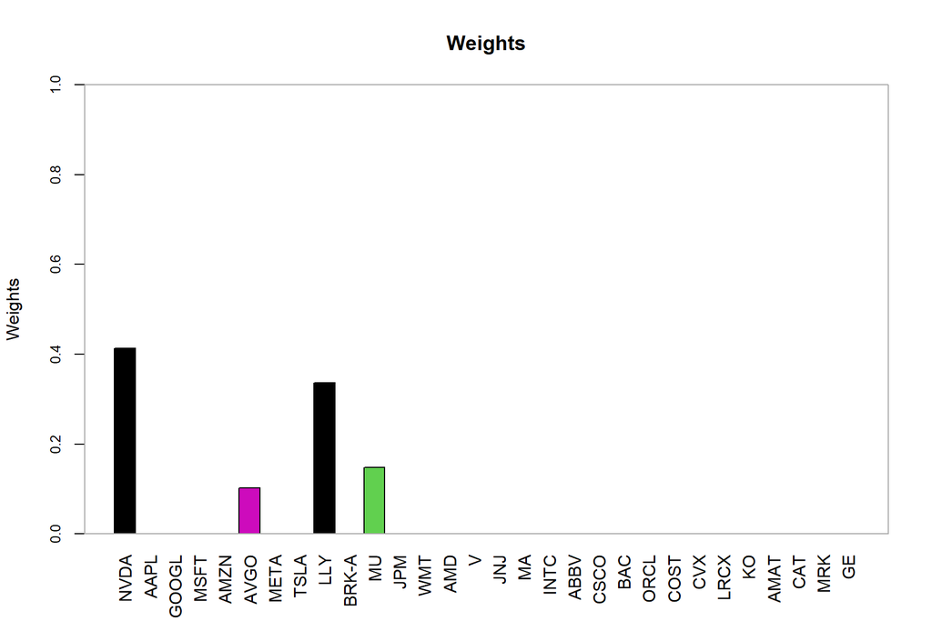

```r
chart.Weights(opt.pos,
              plot.type = "barplot",
              legend.loc = NULL,
              ylim = c(0,1))
```

```r
diversification(weights = opt.pos$weights)
```

```
## [1] 0.6839817
```

```r
SharpeRatio(R = retornos_mes, Rf = 0, weights = opt.pos$weights, FUN = "StdDev")
```

```
##                                  [,1]
## Sharpe Ratio (Rf=0%, p=95%): 0.418648
```

```r
sum(opt.pos$weights)
```

```
## [1] 1
```

## 6. M-ES: maximizando el Sharpe con Expected Shortfall

**Qué hace:** cambia la medida de riesgo de $\sigma$ a **ES al 95%**, el promedio de las pérdidas más allá del VaR. **Por qué (teoría):** la desviación estándar penaliza por igual subidas y bajadas y no ve las colas; el ES sí mide la severidad de la cola de pérdidas y es una medida de riesgo **coherente** (subaditiva), a diferencia del VaR.

```r
es.portfolio <- PortfolioAnalytics::portfolio.spec(assets = activos)

## 6.2. Restricciones ----

### 6.2.1. Uso de todo el capital ----

es.portfolio <- PortfolioAnalytics::add.constraint(portfolio = es.portfolio,
                                                   type = "full_investment")

### 6.2.2. No short selling ----

es.portfolio <- PortfolioAnalytics::add.constraint(portfolio = es.portfolio,
                                                   type = "long_only")

## 6.3. Objetivos ----

### 6.3.1. Riesgo como desviacion estandar ----

es.portfolio <- PortfolioAnalytics::add.objective(portfolio = es.portfolio,
                                                  type = "risk",
                                                  name = "ES",
                                                  arguments = list(p = 0.95))

### 6.3.2. Rentabilidad como media de los retornos ----

es.portfolio <- PortfolioAnalytics::add.objective(portfolio = es.portfolio,
                                                  type = "return",
                                                  name = "mean")

summary(es.portfolio)
```

```
## $assets
##       NVDA       AAPL      GOOGL       MSFT       AMZN       AVGO       META
## 0.03333333 0.03333333 0.03333333 0.03333333 0.03333333 0.03333333 0.03333333
##       TSLA        LLY      BRK-A         MU        JPM        WMT        AMD
## 0.03333333 0.03333333 0.03333333 0.03333333 0.03333333 0.03333333 0.03333333
##          V        JNJ         MA       INTC       ABBV       CSCO        BAC
## 0.03333333 0.03333333 0.03333333 0.03333333 0.03333333 0.03333333 0.03333333
##       ORCL       COST        CVX       LRCX         KO       AMAT        CAT
## 0.03333333 0.03333333 0.03333333 0.03333333 0.03333333 0.03333333 0.03333333
##        MRK         GE
## 0.03333333 0.03333333
##
## $enabled_constraints
## $enabled_constraints[[1]]
## $type
## [1] "full_investment"
##
## $enabled
## [1] TRUE
##
## $message
## [1] FALSE
##
## $min_sum
## [1] 1
##
## $max_sum
## [1] 1
##
## $call
## PortfolioAnalytics::add.constraint(portfolio = es.portfolio,
##     type = "full_investment")
##
## attr(,"class")
## [1] "weight_sum_constraint" "constraint"
##
## $enabled_constraints[[2]]
## $type
## [1] "long_only"
##
```

[output cut: 73 more lines]

```
## [1] -1
##
## $call
## PortfolioAnalytics::add.objective(portfolio = es.portfolio, type = "return",
##     name = "mean")
##
## attr(,"class")
## [1] "return_objective" "objective"
##
##
## $disabled_objectives
## list()
##
## attr(,"class")
## [1] "summary.portfolio"
```

```r
opt.es <- PortfolioAnalytics::optimize.portfolio(R = retornos_mes,
                                                 portfolio = es.portfolio,
                                                 optimize_method = "ROI",
                                                 trace = T,
                                                 maxSR = TRUE)
opt.es
```

```
## PortfolioAnalytics Optimization
##
## Call:
## PortfolioAnalytics::optimize.portfolio(R = retornos_mes, portfolio = es.portfolio,
##     optimize_method = "ROI", trace = T, maxSR = TRUE)
##
## Optimal Weights:
##   NVDA   AAPL  GOOGL   MSFT   AMZN   AVGO   META   TSLA    LLY  BRK-A     MU
## 0.0000 0.0000 0.0000 0.0000 0.0000 0.0335 0.0000 0.0000 0.1542 0.0000 0.0000
##    JPM    WMT    AMD      V    JNJ     MA   INTC   ABBV   CSCO    BAC   ORCL
## 0.0000 0.0000 0.0000 0.0000 0.0000 0.0000 0.0000 0.1801 0.0000 0.0000 0.0000
##   COST    CVX   LRCX     KO   AMAT    CAT    MRK     GE
## 0.1517 0.1768 0.0000 0.0000 0.0000 0.0000 0.2455 0.0583
##
## Objective Measure:
##    mean
## 0.01792
##
##
##      ES
## 0.03896
```

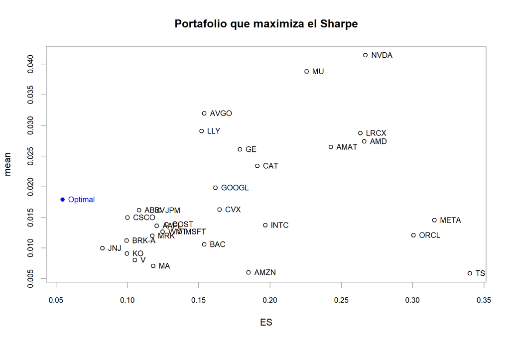

```r
PortfolioAnalytics::chart.RiskReward(opt.es,
                                     risk.col = "ES",
                                     return.col = "mean",
                                     chart.assets = TRUE,
                                     rp = F,
                                     main = "Portafolio que maximiza el Sharpe")
```

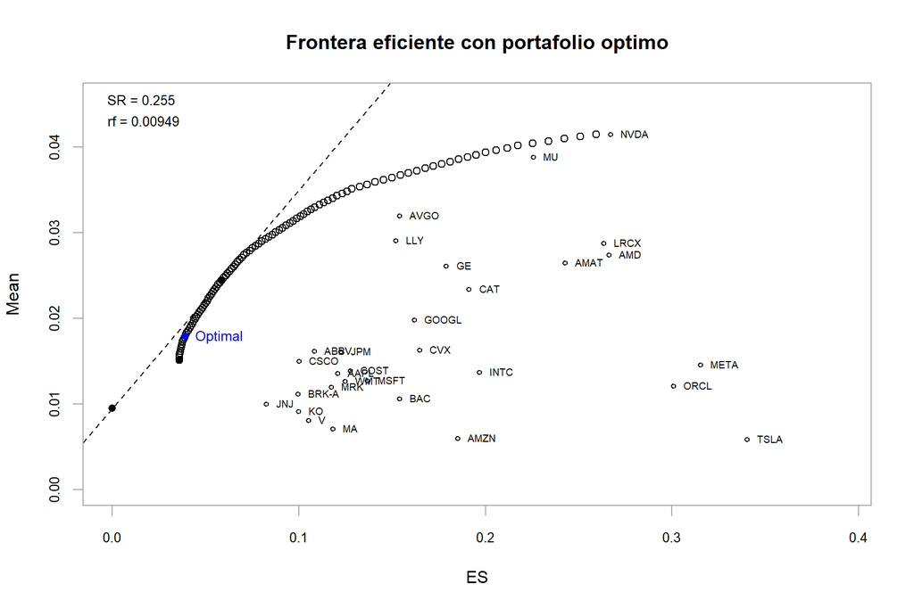

```r
PortfolioAnalytics::chart.EfficientFrontier(opt.es,
                                            match.col = 'ES',
                                            main = "Frontera eficiente con portafolio optimo",
                                            cex.assets = 0.6,
                                            tangent.line = T,
                                            n.portfolios = 100,
                                            rf = free_rate)
```

```r
## 6.5. Resultados ----

summary(opt.es)
```

```
## PortfolioAnalytics Optimization Summary
##
## Call:
## PortfolioAnalytics::optimize.portfolio(R = retornos_mes, portfolio = es.portfolio,
##     optimize_method = "ROI", trace = T, maxSR = TRUE)
##
## Optimal Weights:
##   NVDA   AAPL  GOOGL   MSFT   AMZN   AVGO   META   TSLA    LLY  BRK-A     MU
## 0.0000 0.0000 0.0000 0.0000 0.0000 0.0335 0.0000 0.0000 0.1542 0.0000 0.0000
##    JPM    WMT    AMD      V    JNJ     MA   INTC   ABBV   CSCO    BAC   ORCL
## 0.0000 0.0000 0.0000 0.0000 0.0000 0.0000 0.0000 0.1801 0.0000 0.0000 0.0000
##   COST    CVX   LRCX     KO   AMAT    CAT    MRK     GE
## 0.1517 0.1768 0.0000 0.0000 0.0000 0.0000 0.2455 0.0583
##
## Objective Measures:
##    mean
## 0.01792
##
##
##      ES
## 0.03896
##
##
## Portfolio Assets and Initial Weights:
##       NVDA       AAPL      GOOGL       MSFT       AMZN       AVGO       META
## 0.03333333 0.03333333 0.03333333 0.03333333 0.03333333 0.03333333 0.03333333
##       TSLA        LLY      BRK-A         MU        JPM        WMT        AMD
## 0.03333333 0.03333333 0.03333333 0.03333333 0.03333333 0.03333333 0.03333333
##          V        JNJ         MA       INTC       ABBV       CSCO        BAC
## 0.03333333 0.03333333 0.03333333 0.03333333 0.03333333 0.03333333 0.03333333
##       ORCL       COST        CVX       LRCX         KO       AMAT        CAT
## 0.03333333 0.03333333 0.03333333 0.03333333 0.03333333 0.03333333 0.03333333
##        MRK         GE
## 0.03333333 0.03333333
##
## PortfolioAnalytics Portfolio Specification
##
## Call:
## PortfolioAnalytics::portfolio.spec(assets = activos)
##
```

[output cut: 108 more lines]

```
## [1] TRUE
##
## $multiplier
## [1] -1
##
## $call
## PortfolioAnalytics::add.objective(portfolio = es.portfolio, type = "return",
##     name = "mean")
##
## attr(,"class")
## [1] "return_objective" "objective"
##
##
## Elapsed Time:
## Time difference of 0.908283 secs
```

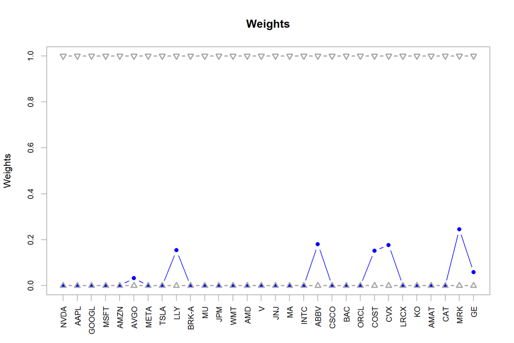

```r
chart.Weights(opt.es)
```

```r
diversification(weights = opt.es$weights)
```

```
## [1] 0.8247483
```

```r
SharpeRatio(R = retornos_mes, Rf = 0, weights = opt.es$weights, FUN = "StdDev")
```

```
##                                   [,1]
## Sharpe Ratio (Rf=0%, p=95%): 0.4450366
```

## 7. M-ES con grupos, inversión parcial y cortos limitados

**Qué hace:** suma de pesos fija en **70%** (el 30% restante queda fuera, p. ej. en el activo libre de riesgo), pesos individuales entre −5% y 100% (cortos pequeños permitidos) y límites por grupo que también admiten posiciones netas cortas. **Por qué (teoría):** al permitir cortos el conjunto factible crece, y al fijar la suma en 0,7 el portafolio ya no es “completamente invertido”: el Sharpe se evalúa con $R_f$ sobre lo invertido.

```r
gr.es.portfolio <- PortfolioAnalytics::portfolio.spec(assets = activos)

## 7.2 Restricciones ----

### 7.2.1. Uso de todo el capital ----

gr.es.portfolio <- PortfolioAnalytics::add.constraint(portfolio = gr.es.portfolio,
                                                   type = "weight_sum",
                                                   min_sum = 0.7,
                                                   max_sum = 0.7)

### 7.2.2. No short selling ----

gr.es.portfolio <- PortfolioAnalytics::add.constraint(portfolio = gr.es.portfolio,
                                                   type = "box",
                                                   min = -0.05,
                                                   max = 1)

### 7.2.3. Restricciones de peso de los grupos ----

gr.es.portfolio <- add.constraint(portfolio = gr.es.portfolio,
                               type = "group",
                               groups = list(Tech = c(1:8,11,14,18,20,22,25,27),
                                             Pharma = c(9,16,29),
                                             Financial = c(10,12,15,17,21),
                                             Other = c(13,19,23,24,26,28,30)),
                               group_min = c(-0.3, -0.3, -0.2, -0.2),
                               group_max = c(0.4, 0.4, 0.3, 0.2))

summary(gr.es.portfolio)
```

```
## $assets
##       NVDA       AAPL      GOOGL       MSFT       AMZN       AVGO       META
## 0.03333333 0.03333333 0.03333333 0.03333333 0.03333333 0.03333333 0.03333333
##       TSLA        LLY      BRK-A         MU        JPM        WMT        AMD
## 0.03333333 0.03333333 0.03333333 0.03333333 0.03333333 0.03333333 0.03333333
##          V        JNJ         MA       INTC       ABBV       CSCO        BAC
## 0.03333333 0.03333333 0.03333333 0.03333333 0.03333333 0.03333333 0.03333333
##       ORCL       COST        CVX       LRCX         KO       AMAT        CAT
## 0.03333333 0.03333333 0.03333333 0.03333333 0.03333333 0.03333333 0.03333333
##        MRK         GE
## 0.03333333 0.03333333
##
## $enabled_constraints
## $enabled_constraints[[1]]
## $type
## [1] "weight_sum"
##
## $enabled
## [1] TRUE
##
## $message
## [1] FALSE
##
## $min_sum
## [1] 0.7
##
## $max_sum
## [1] 0.7
##
## $call
## PortfolioAnalytics::add.constraint(portfolio = gr.es.portfolio,
##     type = "weight_sum", min_sum = 0.7, max_sum = 0.7)
##
## attr(,"class")
## [1] "weight_sum_constraint" "constraint"
##
## $enabled_constraints[[2]]
## $type
## [1] "box"
##
```

[output cut: 63 more lines]

```
## attr(,"class")
## [1] "group_constraint" "constraint"
##
##
## $disabled_constraints
## list()
##
## $enabled_objectives
## list()
##
## $disabled_objectives
## list()
##
## attr(,"class")
## [1] "summary.portfolio"
```

```r
gr.es.portfolio <- PortfolioAnalytics::add.objective(portfolio = gr.es.portfolio,
                                                  type = "risk",
                                                  name = "ES")

### 7.3.2. Rentabilidad como media de los retornos ----

gr.es.portfolio <- PortfolioAnalytics::add.objective(portfolio = gr.es.portfolio,
                                                  type = "return",
                                                  name = "mean")

summary(gr.es.portfolio)
```

```
## $assets
##       NVDA       AAPL      GOOGL       MSFT       AMZN       AVGO       META
## 0.03333333 0.03333333 0.03333333 0.03333333 0.03333333 0.03333333 0.03333333
##       TSLA        LLY      BRK-A         MU        JPM        WMT        AMD
## 0.03333333 0.03333333 0.03333333 0.03333333 0.03333333 0.03333333 0.03333333
##          V        JNJ         MA       INTC       ABBV       CSCO        BAC
## 0.03333333 0.03333333 0.03333333 0.03333333 0.03333333 0.03333333 0.03333333
##       ORCL       COST        CVX       LRCX         KO       AMAT        CAT
## 0.03333333 0.03333333 0.03333333 0.03333333 0.03333333 0.03333333 0.03333333
##        MRK         GE
## 0.03333333 0.03333333
##
## $enabled_constraints
## $enabled_constraints[[1]]
## $type
## [1] "weight_sum"
##
## $enabled
## [1] TRUE
##
## $message
## [1] FALSE
##
## $min_sum
## [1] 0.7
##
## $max_sum
## [1] 0.7
##
## $call
## PortfolioAnalytics::add.constraint(portfolio = gr.es.portfolio,
##     type = "weight_sum", min_sum = 0.7, max_sum = 0.7)
##
## attr(,"class")
## [1] "weight_sum_constraint" "constraint"
##
## $enabled_constraints[[2]]
## $type
## [1] "box"
##
```

[output cut: 110 more lines]

```
## [1] -1
##
## $call
## PortfolioAnalytics::add.objective(portfolio = gr.es.portfolio,
##     type = "return", name = "mean")
##
## attr(,"class")
## [1] "return_objective" "objective"
##
##
## $disabled_objectives
## list()
##
## attr(,"class")
## [1] "summary.portfolio"
```

```r
## 7.4. Optimizacion ----

opt.gr.es <- PortfolioAnalytics::optimize.portfolio(R = retornos_mes,
                                                 portfolio = gr.es.portfolio,
                                                 optimize_method = "ROI",
                                                 trace = T,
                                                 maxSR = TRUE)
opt.gr.es
```

```
## PortfolioAnalytics Optimization
##
## Call:
## PortfolioAnalytics::optimize.portfolio(R = retornos_mes, portfolio = gr.es.portfolio,
##     optimize_method = "ROI", trace = T, maxSR = TRUE)
##
## Optimal Weights:
##    NVDA    AAPL   GOOGL    MSFT    AMZN    AVGO    META    TSLA     LLY   BRK-A
## -0.0137  0.0805 -0.0031 -0.0500 -0.0500  0.1739 -0.0500 -0.0338  0.0637  0.0351
##      MU     JPM     WMT     AMD       V     JNJ      MA    INTC    ABBV    CSCO
##  0.0489  0.0420 -0.0453  0.0467  0.0323 -0.0500 -0.0500 -0.0500  0.0944  0.2078
##     BAC    ORCL    COST     CVX    LRCX      KO    AMAT     CAT     MRK      GE
## -0.0500 -0.0500  0.1237  0.0725 -0.0500 -0.0500 -0.0500 -0.0500  0.3198  0.0546
##
## Objective Measure:
##    mean
## 0.01568
##
##
##      ES
## 0.02036
```

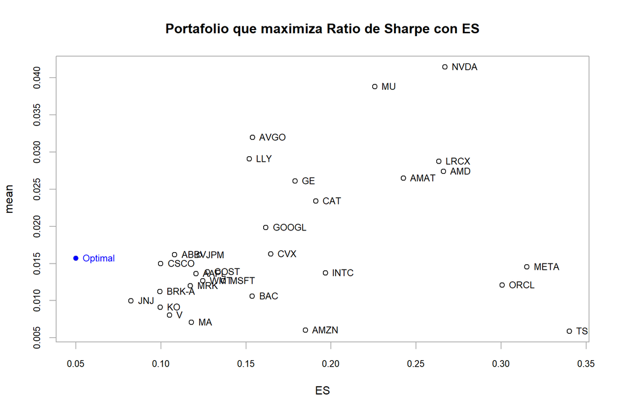

```r
PortfolioAnalytics::chart.RiskReward(opt.gr.es,
                                     risk.col = "ES",
                                     return.col = "mean",
                                     chart.assets = TRUE,
                                     main = "Portafolio que maximiza Ratio de Sharpe con ES")
```

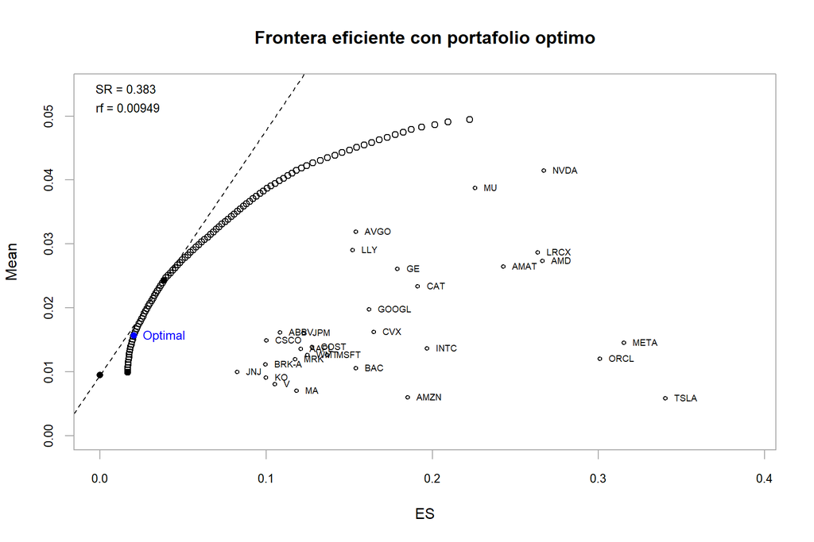

```r
PortfolioAnalytics::chart.EfficientFrontier(opt.gr.es,
                                            match.col = 'ES',
                                            main = "Frontera eficiente con portafolio optimo",
                                            cex.assets = 0.6,
                                            tangent.line = T,
                                            rf = free_rate,
                                            n.portfolios = 100)
```

```r
summary(opt.gr.es)
```

```
## PortfolioAnalytics Optimization Summary
##
## Call:
## PortfolioAnalytics::optimize.portfolio(R = retornos_mes, portfolio = gr.es.portfolio,
##     optimize_method = "ROI", trace = T, maxSR = TRUE)
##
## Optimal Weights:
##    NVDA    AAPL   GOOGL    MSFT    AMZN    AVGO    META    TSLA     LLY   BRK-A
## -0.0137  0.0805 -0.0031 -0.0500 -0.0500  0.1739 -0.0500 -0.0338  0.0637  0.0351
##      MU     JPM     WMT     AMD       V     JNJ      MA    INTC    ABBV    CSCO
##  0.0489  0.0420 -0.0453  0.0467  0.0323 -0.0500 -0.0500 -0.0500  0.0944  0.2078
##     BAC    ORCL    COST     CVX    LRCX      KO    AMAT     CAT     MRK      GE
## -0.0500 -0.0500  0.1237  0.0725 -0.0500 -0.0500 -0.0500 -0.0500  0.3198  0.0546
##
## Objective Measures:
##    mean
## 0.01568
##
##
##      ES
## 0.02036
##
##
## Portfolio Assets and Initial Weights:
##       NVDA       AAPL      GOOGL       MSFT       AMZN       AVGO       META
## 0.03333333 0.03333333 0.03333333 0.03333333 0.03333333 0.03333333 0.03333333
##       TSLA        LLY      BRK-A         MU        JPM        WMT        AMD
## 0.03333333 0.03333333 0.03333333 0.03333333 0.03333333 0.03333333 0.03333333
##          V        JNJ         MA       INTC       ABBV       CSCO        BAC
## 0.03333333 0.03333333 0.03333333 0.03333333 0.03333333 0.03333333 0.03333333
##       ORCL       COST        CVX       LRCX         KO       AMAT        CAT
## 0.03333333 0.03333333 0.03333333 0.03333333 0.03333333 0.03333333 0.03333333
##        MRK         GE
## 0.03333333 0.03333333
##
## PortfolioAnalytics Portfolio Specification
##
## Call:
## PortfolioAnalytics::portfolio.spec(assets = activos)
##
```

[output cut: 132 more lines]

```
## [1] TRUE
##
## $multiplier
## [1] -1
##
## $call
## PortfolioAnalytics::add.objective(portfolio = gr.es.portfolio,
##     type = "return", name = "mean")
##
## attr(,"class")
## [1] "return_objective" "objective"
##
##
## Elapsed Time:
## Time difference of 0.6099801 secs
```

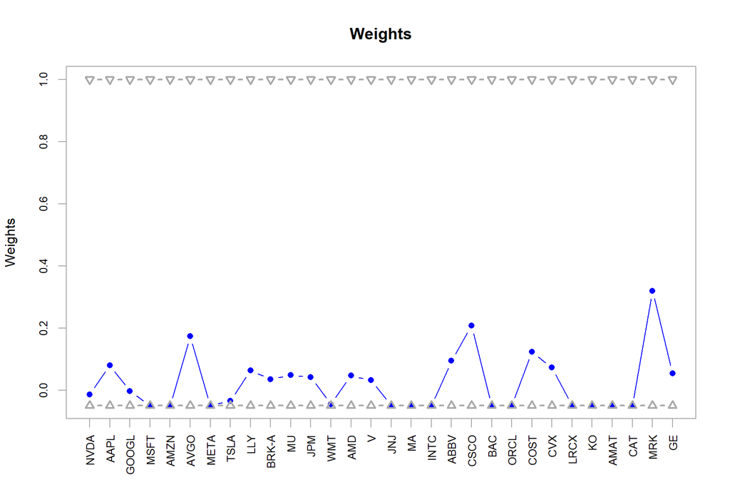

```r
chart.Weights(opt.gr.es)
```

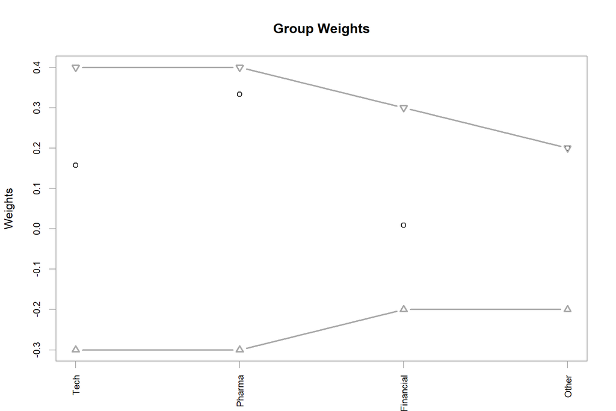

```r
chart.GroupWeights(opt.gr.es)
```

```r
diversification(weights = opt.gr.es$weights)
```

```
## [1] 0.7393165
```

```r
SharpeRatio(R = retornos_mes, Rf = free_rate, weights = opt.gr.es$weights, FUN = "StdDev")
```

```
##                                     [,1]
## Sharpe Ratio (Rf=0.9%, p=95%): 0.2396967
```

```r
sum(opt.gr.es$weights)
```

```
## [1] 0.7
```